# Tarea1_AlejandroBarrantes

Alejandro Barrantes Castro

2023-03-15

## Ejercicio 1

### 1.a

#### **Estadística:** Es una rama de las matemáticas que se centra en la recolección, análisis e interpretación de datos. Se utiliza para describir los datos de una manera grafica y sencilla de visualizar o entender.

#### **Análisis de Datos:** Como lo dice su nombre, Es el proceso de examinar datos con el fin de obtener información útil y tomar decisiones informadas. Es un proceso muy importante, ya que permite encontrar diferentes patrones o pistas en los datos recolectados.

#### **Mineria de Datos:** Es el proceso de descubrir patrones y relaciones en grandes conjuntos de datos utilizando técnicas de inteligencia artificial, estadísticas y aprendizaje automático, ademas de diferentes lenguajes de programacion.

#### **Machine Learning:** Es una rama de la inteligencia artificial que se centra en el desarrollo de algoritmos que pueden aprender de los datos. Se ejecuta automaticamente y mediante los datos que recolecta atraves del tiempo, desarrolla un conocimiento mas amplio que le permite ejecutar muchas tareas.

#### **Big Data:** Son grandes conjuntos de datos, los cuales no pueden ser procesados o analizados utilizando herramientas de software tradicionales.

#### **Ciencia de Datos:** Es la combinacion completa, ya que incluye desde estadística, aprendizaje automático, minería de datos hasta visualización de datos para analizar y obtener información útil a partir de los datos para corporaciones o empresas y asi puedan aumentar su alcance, ventas, publicidad, clientes, etc.

### 1.b

#### Estan altamente relacionadas, ya que el avance de una le ha permitido a la otra desarrollarse tambien. Desde que el almacenamiento al que podemos acceder es mucho mas grande y economico, el numero y cantidad de datos, estadisticas, recopilaciones, etc que almacenamos ha crecido tambien. Por lo tanto al tener mas almacenamiento, permite tener mas datos recopilados con facilidad.

# ===================================================

## Ejercicio 2

### 2.1: Introduzca x y y como vectores en R

```r
x <- c(3, -5, 31, -1, -9, 10, 0, 18)
y <- c(1, 1, -3, 1, -99, -10, 10, -7)
```

### 2.2 Calcule la media, la varianza, la raiz cuadrada y la desviacion estandar de y

```r
print(mean(y))
```

```
## [1] -13.25
```

```r
print(var(y))
```

```
## [1] 1236.786
```

```r
print(sqrt(y))
```

```
## [1] 1.000000 1.000000      NaN 1.000000      NaN      NaN 3.162278      NaN
```

```r
print(sd(y))
```

```
## [1] 35.16796
```

### 2.3 Calcule la media, la varianza, la raiz cuadrada y la desviacion estandar de x

```r
print(mean(x))
```

```
## [1] 5.875
```

```r
print(var(x))
```

```
## [1] 174.9821
```

```r
print(sqrt(x))
```

```
## [1] 1.732051      NaN 5.567764      NaN      NaN 3.162278 0.000000 4.242641
```

```r
print(sd(x))
```

```
## [1] 13.22808
```

### 2.4 Calcule la correlacion entre x y y.

```r
print(cor(x,y))
```

```
## [1] 0.3659679
```

### 2.5 Escriba un comando en R para extraer las entradas 2 a la 7 de x.

```r
print(x[2:7])
```

```
## [1] -5 31 -1 -9 10  0
```

### 2.6 Escriba un comando en R para extraer las entradas de y excepto la 2 y la 7.

```r
print(y[-c(2,7)])
```

```
## [1]   1  -3   1 -99 -10  -7
```

### 2.7 Escriba un comando en R para extraer las entradas de y menores a -3 o mayores a 10.

```r
menores.3.mayores.10 <- y<(-3) | y>10
print(y[menores.3.mayores.10])
```

```
## [1] -99 -10  -7
```

### 2.8 Escriba un comando en R para extraer las entradas de x mayores a 0 y que sean numeros

### pares.

```r
mayores.0.pares <- x>(0) & x%%2==0
print(x[mayores.0.pares])
```

```
## [1] 10 18
```

# ==============================================================

## Ejercicio 3

```r
A<-matrix(c(1,2,3,4,5,6,7,8,9,10,11,12),nrow=4,"byrow"="true")
print(A)
```

```
##      [,1] [,2] [,3]
## [1,]    1    2    3
## [2,]    4    5    6
## [3,]    7    8    9
## [4,]   10   11   12
```

```r
A[1,1:3]
```

```
## [1] 1 2 3
```

### Se obtienen numeros desde la posicion (1,1), 3 hacia la derecha

```r
A[1:4,2]
```

```
## [1]  2  5  8 11
```

### Se obtienen numeros desde la fila 1 a la 4, en la 2da columna, osea verticalmente

```r
A[3,3]
```

```
## [1] 9
```

### Se obtienen el numero de la posicion (3,3) en la matriz. Fila 3, columna 3

```r
A[11]
```

```
## [1] 9
```

### Se obtienen el numero 9, ya que es el numero #11 en la matriz si contamos de fila en fila verticalmente

```r
A[20]
```

```
## [1] NA
```

### Se obtienen NA, ya que la matriz no cuenta con mas de 12 posiciones, por lo tanto A[20] va a ser nulo

```r
# A[5,4]
```

### Genera error, ya que no existe tal entrada o posicion en la matriz, debido a que es una matriz 4x3.

```r
#A[1,1,1]
```

### La matriz es de una dimension (x,y), y en el codigo esta pidiendo una posicion en la matriz (x,y,z), por lo tanto, va a generar un error, ya que son dimensiones diferentes

# ==============================================================

## Ejercicio 4

### El comando ‘as.matrix’ funciona para convertir un objeto en una matriz, estos objetos pueden ser estructuras de datos como dataframes, vectores o listas. Ejemplo: Supongamos que tenemos el siguiente dataframe y lo convertimos a matriz:

```r
df <- data.frame(a = c(1,2,3,4), b = c(5,6,7,8), c = c(9,10,11,12))
matriz <- as.matrix(df)
matriz
```

```
##      a b  c
## [1,] 1 5  9
## [2,] 2 6 10
## [3,] 3 7 11
## [4,] 4 8 12
```

### El comando ‘as.data.frame’ funciona para convertir un objeto en un dataframe, estos objetos pueden ser estructuras de datos como matrices, vectores o listas. Ejemplo: Utilizaremos la matriz anterior, ahora la convertimos a data frame de nuevo:

```r
df <- as.data.frame(matriz)
df
```

```
##   a b  c
## 1 1 5  9
## 2 2 6 10
## 3 3 7 11
## 4 4 8 12
```

# ================================================================

## Ejercicio 5

```r
mi_df <- data.frame(
  "Peso" = c(76,67,55,57,87,48),
  "Edad" = c(25,23,19,18,57,13),
  "Nivel Educativo" = c("Lic","Bach","Bach","Bach","Dr","Msc")
)

(mi_df)
```

```
##   Peso Edad Nivel.Educativo
## 1   76   25             Lic
## 2   67   23            Bach
## 3   55   19            Bach
## 4   57   18            Bach
## 5   87   57              Dr
## 6   48   13             Msc
```

# ==================================================================

## Ejercicio 6

### 6.1 y = (2, 4, 6, 8), as´ı definido y es el vector formado por las componentes positivas de x.

```r
x <- c(2, -5, 4, 6, -2, 8)

y<-x>0
y<-c(x[y])
print(y)
```

```
## [1] 2 4 6 8
```

### 6.2 z = (−5, −2), as´ı definido z es el vector formado por las componentes negativas de x.

```r
negativos<- x<0
z<-c(x[negativos])
print(z)
```

```
## [1] -5 -2
```

### 6.3 v = (−5, 4, 6, −2, 8), as´ı definido v es el vector x eliminada la primera componente.

```r
v<-c(x[-1])
print(v)
```

```
## [1] -5  4  6 -2  8
```

### 6.4 w = (2, 4, −2), as´ı definido w es el vector x tomando las componentes con ´ındice impares, es decir, x[1] = 2, x[3] = 4 y x[5] = −2.

```r
w <- x[c(1, 3, 5)]
print(w)
```

```
## [1]  2  4 -2
```

# ===================================================

## Ejercicio 7

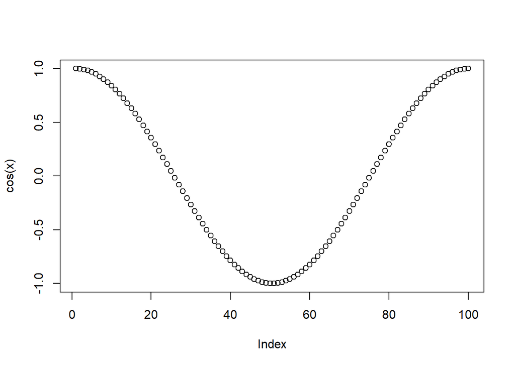

```r
x<-seq(0,2*pi,length=100)
plot(cos(x))
```

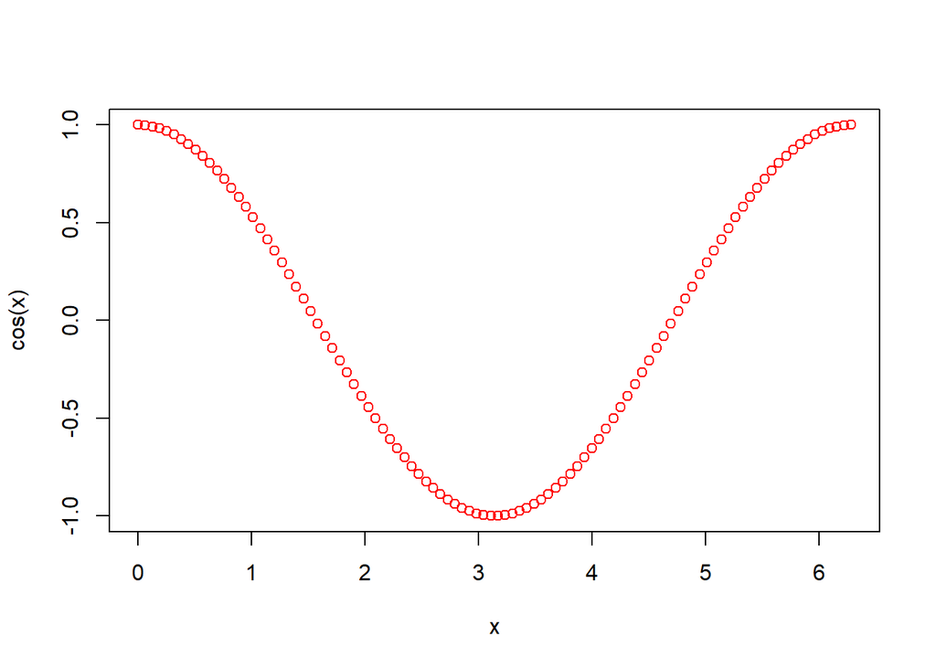

```r
plot(x,cos(x),col="red")
```

### En el primer caso, utiliza valores predeterminados para x, y en el segundo, especifica que deben ser coseno de x, ademas de que utiliza el color rojo para poder tener una mejor compresion del grafico